# Sampling, modeling, experiments that might get at age-0 and age-1 survival-Pradel Model

Michael E. Colvin

14 July 2016

## Background

The information contained in capture histories informs the survival from one time interval to the next.  
This informaion when viewed in reverse order contains information on entry into the population. Specifically, prior to being captured a critter is either at large (present but not captured) or not present (i.e., unborn). Therefore looking at capture histories in reverse order estimtates ‘recruitment’. Typical with capture-mark-recapture approaches estimated parameters can be estimated and related to covariates.

The Pradel model originally developed by Pradel back in the 70s estimates survival and recruitment using this reversal symmetry. Essentially, when looking at a capture history of a fish in reverse with particular examination of the preceeding 0s. Suppose a capture history of a fish is 00010101, on the first 3 occassions a fish could be alive and uncaptured or waiting to be born. Using this information a cmr program may be able to simulaneously model survival and recruitment. This is appealing because recruitment can be thought of simply surviving age-0 or age-1 which can be related to covariates. Thinking outside of the box on this one might be able to model the effect of environmental covariates hypothesized to influence recruitment.

The objective of this brief is to explore whether this might make sense. It is not a full proof of concept but a simple what if. Therefore the usual caveats are at work here, specifically this might work well on a computer but may fail miserably in the field.

## Simulating some known data.

To test the approach we need to simulate some data from some known parameters.  
The Pradel model estimates $\phi$, $p$, and $f$, where these values represent survival, capture probability, and recruitment rate.

For the simualion I simulated 10 occasions, coudld be 10 years, 10 months, so on.

- Survival $\phi$ was set at 0.8
- Capture probability $p$ was set at 0.3
- Recruitment rate $f$ was set at 0.195 (i.e., Recruits = $f$*Abundance)
- Intial population was set to be 2000 critters

```r
# SIMULATE POPULATION AND CAPTURE HISTORIES
n_occ<- 10
phi<- rep(0.8,n_occ-1)
p<- rep(0.3,n_occ)
f<- 0.195
n<- 2000 # initial population size
R<- c(n)
for(i in 2:n_occ)
    {
    R<- c(R,rpois(1,n[i-1]*f))
    n<- c(n, rbinom(1,n[i-1],phi)+R[i])
    }
super_n<- sum(R) # total population
# WHEN DO CRITTERS RECRUIT TO THE POPULATION?
ent<-rep(c(1:length(R)),R)
ch<-Z<- matrix(0,super_n,n_occ)
for(i in 1:super_n)
    {
    Z[i,ent[i]]<-1
    indx<- ent[i]+1
    if(indx<=n_occ)
        {
        for(j in indx:n_occ)
            {
            Z[i,j]<- rbinom(1,1,phi[j-1]*Z[i,j-1])
            }
        }
    }
```

The code above simulates a population of indviduals given a recruitment rate where the number of recruits is a function of the population in this case. It may not be in some cases and this can be account for in the Pradel formulation. Now we can look at the ‘true’ population dynamics.

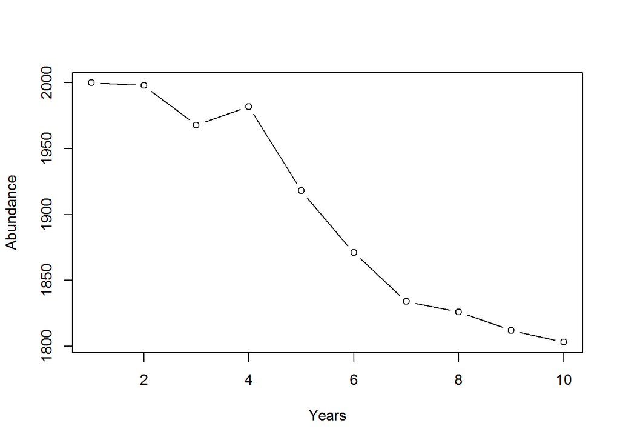

```r
plot(colSums(Z),type='b',ylab="Abundance",xlab="Years")
```

Now we can use the ‘true’ population dynamics to simulate the capture process and make some capture histories.

```r
# SIMULATE CAPTURE HISTORY
for(i in 1:super_n)
    {
    for(j in 1:n_occ)
        {
        ch[i,j]<- rbinom(1,1,p[j]*Z[i,j])
        }
    }
```

In the capture histories there are fish that were present but not captured, we need to drop those from the histories.

```r
ch<- ch[which(apply(ch,1,sum)!=0),]
```

The library ‘Rmark’ gets us access to program mark through R which we can we to set up the capture histories and design matrices.

```r
library(RMark)
```

```r
# PROCESS CPATURE HISTORIES INTO A DATA.FRAME
ch<- data.frame(ch=apply(ch,1, paste,collapse=""),stringsAsFactors = FALSE)
# PROCESS CPATURE HISTORIES INTO A LIST FOR MARK
ch_proc<- process.data(ch,model="Pradrec", begin.time=2005)
# MAKE THE DESIGN MATRIX FOR THE CMR DATA
ddl<-make.design.data(ch_proc)
```

Now that the data is all set up we can feed some formulas for $\phi$, $p$, and $f$ to MARK for estimation. These are all time invariant formulations (i.e.,$\phi$, $p$, and $f$ are constant over time).

```r
Phi.dot=list(formula=~1)
p.dot=list(formula=~1)
f.dot=list(formula=~1)
m1<-mark(ch_proc,ddl,model.parameters=list(Phi=Phi.dot,p=p.dot,f=f.dot))
```

```
##
## Output summary for Pradrec model
## Name : Phi(~1)p(~1)f(~1)
##
## Npar :  3
## -2lnL:  28143.53
## AICc :  28149.54
##
## Beta
##                   estimate        se        lcl        ucl
## Phi:(Intercept)  1.3384548 0.0382286  1.2635269  1.4133828
## p:(Intercept)   -0.8455734 0.0337063 -0.9116377 -0.7795092
## f:(Intercept)   -1.6355734 0.0336702 -1.7015669 -1.5695798
##
##
## Real Parameter Phi
##       2005      2006      2007      2008      2009      2010      2011
##  0.7922357 0.7922357 0.7922357 0.7922357 0.7922357 0.7922357 0.7922357
##       2012      2013
##  0.7922357 0.7922357
##
##
## Real Parameter p
##       2005      2006      2007      2008      2009      2010      2011
##  0.3003623 0.3003623 0.3003623 0.3003623 0.3003623 0.3003623 0.3003623
##       2012      2013      2014
##  0.3003623 0.3003623 0.3003623
##
##
## Real Parameter f
##       2005      2006      2007      2008      2009      2010      2011
##  0.1948406 0.1948406 0.1948406 0.1948406 0.1948406 0.1948406 0.1948406
##       2012      2013
##  0.1948406 0.1948406
```

You can also recast the model to estimate lambda.

```r
ch_proc<- process.data(ch,model="Pradlambda", begin.time=2005)
ddl<-make.design.data(ch_proc)
Phi.dot=list(formula=~1)
p.dot=list(formula=~1)
Lambda.dot=list(formula=~1)
m1<-mark(ch_proc,ddl,model.parameters=list(Phi=Phi.dot,p=p.dot,Lambda=Lambda.dot))
```

```
##
## Output summary for Pradlambda model
## Name : Phi(~1)p(~1)Lambda(~1)
##
## Npar :  3
## -2lnL:  28143.53
## AICc :  28149.54
##
## Beta
##                      estimate        se        lcl        ucl
## Phi:(Intercept)     1.3384548 0.0382286  1.2635269  1.4133828
## p:(Intercept)      -0.8455734 0.0337063 -0.9116377 -0.7795091
## Lambda:(Intercept) -0.0130079 0.0046937 -0.0222075 -0.0038083
##
##
## Real Parameter Phi
##       2005      2006      2007      2008      2009      2010      2011
##  0.7922357 0.7922357 0.7922357 0.7922357 0.7922357 0.7922357 0.7922357
##       2012      2013
##  0.7922357 0.7922357
##
##
## Real Parameter p
##       2005      2006      2007      2008      2009      2010      2011
##  0.3003623 0.3003623 0.3003623 0.3003623 0.3003623 0.3003623 0.3003623
##       2012      2013      2014
##  0.3003623 0.3003623 0.3003623
##
##
## Real Parameter Lambda
##       2005      2006      2007      2008      2009      2010      2011
##  0.9870764 0.9870764 0.9870764 0.9870764 0.9870764 0.9870764 0.9870764
##       2012      2013
##  0.9870764 0.9870764
```

## Application to AM and the big picture

```r
irc<- c(37,31,24,27,6,32,10,26,6)
# EFFECT OF IRC
B_irc<- 0.008
B_0<- -1.33
f<- exp(B_0 + B_irc*irc)
```

The predicted recruitment as a function of IRC looks like the figure below.

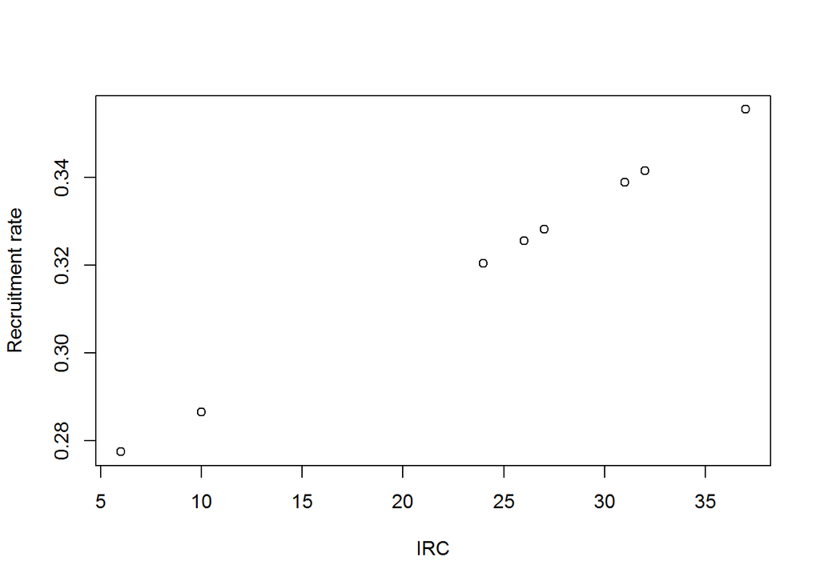

```r
plot(f~irc, ylab="Recruitment rate", xlab="IRC")
```

### Fitting a covariate to recruitment

Using the same code to simulate a population with constant $\phi$ as above but now allowing $f$ to vary over time as a function of IRC we can simulate the population data.

```r
# MODEL AS A FUNCTION OF IRC
n_occ<- 10
phi<- rep(0.8,n_occ-1)
p<- rep(0.3,n_occ)
n<- 2000 # initial population size
R<- c(n)
for(i in 2:n_occ)
    {
    R<- c(R,rpois(1,n[i-1]*f[i-1]))
    n<- c(n, rbinom(1,n[i-1],phi)+R[i])
    }
super_n<- sum(R) # total population
# WHEN DO CRITTERS RECRUIT TO THE POPULATION?
ent<-rep(c(1:length(R)),R)
ch<-Z<- matrix(0,super_n,n_occ)
for(i in 1:super_n)
    {
    Z[i,ent[i]]<-1
    indx<- ent[i]+1
    if(indx<=n_occ)
        {
        for(j in indx:n_occ)
            {
            Z[i,j]<- rbinom(1,1,phi[j-1]*Z[i,j-1])
            }
        }
    }
```

The population dynamics are plotted below.

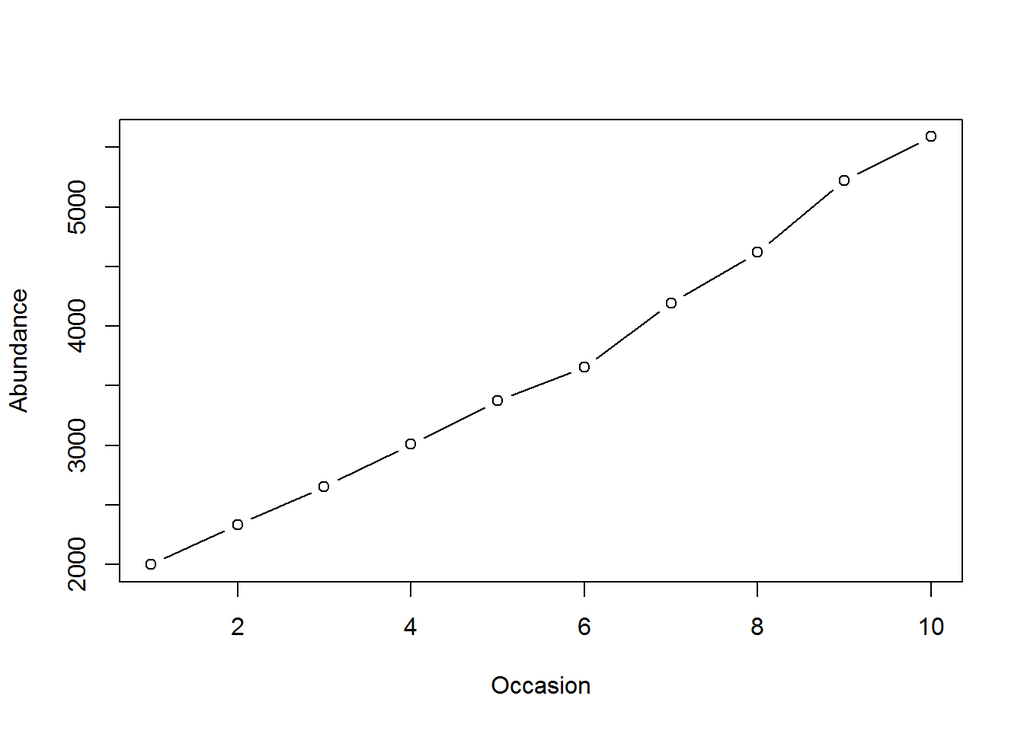

```r
plot(colSums(Z),type='b',ylab="Abundance", xlab="Occasion")
```

Now that we have the true population data we can simulate the capture histories given $p$

```r
# SIMULATE CAPTURE HISTORY
for(i in 1:super_n)
    {
    for(j in 1:n_occ)
        {
        ch[i,j]<- rbinom(1,1,p[j]*Z[i,j])
        }
    }
ch<- ch[which(apply(ch,1,sum)!=0),]
```

Some processing of the simulated data to feed to MARK.

```r
ch<- data.frame(ch=apply(ch,1, paste,collapse=""),stringsAsFactors = FALSE)
ch_proc<- process.data(ch,model="Pradrec", begin.time=2005)
ddl<-make.design.data(ch_proc)
ddl$f$irc<- irc # ADD AMOUNT OF IRC TO USE AS A COVARIATE
```

Now we can do as we did previously but now there is a new bit relating $f$ to IRC `f.irc=list(formula=~irc+1)`.

```r
# FIT PRADEL RECRUITMENT MODEL WITH F A FUNCTION OF IRC
Phi.dot=list(formula=~1)
p.dot=list(formula=~1)
f.irc=list(formula=~irc+1)
m1<-mark(ch_proc,ddl,model.parameters=list(Phi=Phi.dot,p=p.dot,f=f.irc))
```

```
##
## Output summary for Pradrec model
## Name : Phi(~1)p(~1)f(~irc + 1)
##
## Npar :  4
## -2lnL:  52738.82
## AICc :  52746.82
##
## Beta
##                   estimate        se           lcl        ucl
## Phi:(Intercept)  1.3878457 0.0331159  1.3229385000  1.4527530
## p:(Intercept)   -0.8383763 0.0265893 -0.8904914000 -0.7862612
## f:(Intercept)   -1.2489946 0.0658220 -1.3780058000 -1.1199834
## f:irc            0.0050701 0.0030220 -0.0008530237  0.0109933
##
##
## Real Parameter Phi
##       2005      2006      2007      2008      2009      2010      2011
##  0.8002481 0.8002481 0.8002481 0.8002481 0.8002481 0.8002481 0.8002481
##       2012      2013
##  0.8002481 0.8002481
##
##
## Real Parameter p
##       2005      2006      2007      2008      2009      2010      2011
##  0.3018769 0.3018769 0.3018769 0.3018769 0.3018769 0.3018769 0.3018769
##       2012      2013      2014
##  0.3018769 0.3018769 0.3018769
##
##
## Real Parameter f
##       2005      2006     2007      2008      2009     2010      2011
##  0.3459714 0.3356051 0.323903 0.3288674 0.2956515 0.337311 0.3017087
##       2012      2013
##  0.3272042 0.2956515
```

Well the estimates look good, I fed the simulation a $\beta_{0} = -1.33$ and got back -1.2489946. For the effect of IRC I used a $\beta_{1} = 0.008$ and got back 0.0050701.

**Estimates and true values will not exactly match but will improve with more occasions, recaptures, and so on.**

A information theoretic appraoch could be used to evalaute the effect of IRC versus no effect of IRC.

```r
f.dot=list(formula=~1)
f.irc=list(formula=~irc+1)
m1<-mark(ch_proc,ddl,model.parameters=list(Phi=Phi.dot,p=p.dot,f=f.dot))
```

```
##
## Output summary for Pradrec model
## Name : Phi(~1)p(~1)f(~1)
##
## Npar :  3
## -2lnL:  52741.66
## AICc :  52747.66
##
## Beta
##                   estimate        se        lcl        ucl
## Phi:(Intercept)  1.3879614 0.0331861  1.3229168  1.4530061
## p:(Intercept)   -0.8418981 0.0265257 -0.8938884 -0.7899078
## f:(Intercept)   -1.1449630 0.0190810 -1.1823616 -1.1075643
##
##
## Real Parameter Phi
##       2005      2006      2007      2008      2009      2010      2011
##  0.8002666 0.8002666 0.8002666 0.8002666 0.8002666 0.8002666 0.8002666
##       2012      2013
##  0.8002666 0.8002666
##
##
## Real Parameter p
##       2005      2006      2007      2008      2009      2010      2011
##  0.3011352 0.3011352 0.3011352 0.3011352 0.3011352 0.3011352 0.3011352
##       2012      2013      2014
##  0.3011352 0.3011352 0.3011352
##
##
## Real Parameter f
##       2005      2006      2007      2008      2009      2010      2011
##  0.3182357 0.3182357 0.3182357 0.3182357 0.3182357 0.3182357 0.3182357
##       2012      2013
##  0.3182357 0.3182357
```

```r
m2<-mark(ch_proc,ddl,model.parameters=list(Phi=Phi.dot,p=p.dot,f=f.irc))
```

```
##
## Output summary for Pradrec model
## Name : Phi(~1)p(~1)f(~irc + 1)
##
## Npar :  4
## -2lnL:  52738.82
## AICc :  52746.82
##
## Beta
##                   estimate        se           lcl        ucl
## Phi:(Intercept)  1.3878453 0.0331159  1.3229382000  1.4527525
## p:(Intercept)   -0.8383766 0.0265893 -0.8904916000 -0.7862615
## f:(Intercept)   -1.2489972 0.0658201 -1.3780046000 -1.1199898
## f:irc            0.0050703 0.0030219 -0.0008527056  0.0109932
##
##
## Real Parameter Phi
##      2005     2006     2007     2008     2009     2010     2011     2012
##  0.800248 0.800248 0.800248 0.800248 0.800248 0.800248 0.800248 0.800248
##      2013
##  0.800248
##
##
## Real Parameter p
##       2005      2006      2007      2008      2009      2010      2011
##  0.3018768 0.3018768 0.3018768 0.3018768 0.3018768 0.3018768 0.3018768
##       2012      2013      2014
##  0.3018768 0.3018768 0.3018768
##
##
## Real Parameter f
##      2005      2006      2007      2008     2009      2010      2011
##  0.345972 0.3356055 0.3239031 0.3288676 0.295651 0.3373114 0.3017083
##       2012     2013
##  0.3272044 0.295651
```

```r
summary(m1)$AICc # AICc value for m1
```

```
## [1] 52747.66
```

```r
summary(m2)$AICc # AICc value for m2
```

```
## [1] 52746.82
```

With AICc values of 52747.66 and 52746.82 for m1 and m2 respectively there might be some weak evidence for an effect of IRC.

### Fitting a covariate to lambda

Using the same approach we can fit a covariate to lamba. This is not as directly interpretable but simply illustrates the approach.

```r
ch_proc<- process.data(ch,model="Pradlambda", begin.time=2005)
ddl<-make.design.data(ch_proc)
ddl$Lambda$irc<- irc # ADD AMOUNT OF IRC TO USE AS A COVARIATE
Phi.dot=list(formula=~1)
p.dot=list(formula=~1)
Lambda.irc=list(formula=~irc+1)
m1<-mark(ch_proc,ddl,model.parameters=list(Phi=Phi.dot,p=p.dot,Lambda=Lambda.irc))
```

```
##
## Output summary for Pradlambda model
## Name : Phi(~1)p(~1)Lambda(~irc + 1)
##
## Npar :  4
## -2lnL:  52738.85
## AICc :  52746.86
##
## Beta
##                      estimate           se           lcl        ucl
## Phi:(Intercept)     1.3878516 0.0331173000  1.3229417000  1.4527615
## p:(Intercept)      -0.8384405 0.0265871000 -0.8905512000 -0.7863297
## Lambda:(Intercept)  0.0831814 0.0175638000  0.0487563000  0.1176065
## Lambda:irc          0.0014175 0.0008470027 -0.0002426256  0.0030776
##
##
## Real Parameter Phi
##      2005     2006     2007     2008     2009     2010     2011     2012
##  0.800249 0.800249 0.800249 0.800249 0.800249 0.800249 0.800249 0.800249
##      2013
##  0.800249
##
##
## Real Parameter p
##       2005      2006      2007      2008      2009      2010      2011
##  0.3018633 0.3018633 0.3018633 0.3018633 0.3018633 0.3018633 0.3018633
##       2012      2013      2014
##  0.3018633 0.3018633 0.3018633
##
##
## Real Parameter Lambda
##      2005     2006     2007     2008     2009     2010     2011     2012
##  1.145257 1.135558 1.124346 1.129137 1.096021 1.137169 1.102253 1.127538
##      2013
##  1.096021
```

## Caveats

1. This approach may be useful, or not, but may warrant consideration.
2. The approach will not get at abundance and therefor will not be useful for getting at some objectives.
3. It is dependent on many assumptions and conditions and as we all know working on a big river throws some big monkey wrenches.
4. This simulation made a number of simplifying assumptions, constant $\phi$, constant $p$ which may be relaxed to a degree.
5. The consequence of violating the assumptions is always problematic.